# Public-data replication of What can money buy?

Citizens United and simulated state income-tax progressivity

Author

Replication package

# Abstract

This report evaluates a public-data reconstruction of Rebechi et al.’s *What Can Money Buy?* (2026). The reconstruction applies the same national household sample to every jurisdiction’s tax law over 2004–2021, collapses the simulated liabilities to a state-year panel, and estimates the paper’s two-way fixed-effects design.

The headline result is recovered in sign, scale, and conventional clustered inference. For the corporate-and-union-ban group, the replication estimates a top-percentile average-tax-rate effect of −0.67** (0.29), compared with −0.53** (0.24) in the paper’s Table 4. The Reynolds–Smolensky estimate is −0.09** (0.03), compared with −0.11** (0.04) in that table. The reconstruction does not recover the paper’s near-zero overall ATR result: it estimates −0.35** (0.17) where Table 4 reports −0.01 (0.13). The results therefore reproduce the headline distributional pattern, but they are not an exact reproduction of the authors’ unshared data and code.

# 1 Design and data

## 1.1 Pipeline

The reconstruction follows these stages:

- download the public Survey of Consumer Finances summary extract and Federal Reserve macro series;
- return published dollar variables to the source-year dollar convention;
- map the household records into TAXSIM inputs;
- run each fixed household through every state-year tax schedule and collapse the liabilities to outcome indices; and
- estimate the paper’s fixed-effects specifications from the resulting panel.

The committed state-year file is sufficient for every estimate in this report. Only the tax simulation stage needs R and `usincometaxes`; none of the report chunks reruns TAXSIM.

Table 1: Panel and analysis samples

| Sample | Jurisdictions | Years | Observations | Period |
| --- | --- | --- | --- | --- |
| Full committed panel | 51 | 18 | 918 | 2004–2021 |
| Main analysis | 47 | 18 | 846 | 2004–2021 |
| Main analysis excluding DC | 46 | 18 | 828 | 2004–2021 |
| Broad-income-tax sample | 39 | 18 | 702 | 2004–2021 |

As Table 1 shows, the committed panel contains 51 jurisdictions observed for 18 years. The analytic sample excludes Colorado, South Dakota, Nebraska, and Louisiana, retaining 47 jurisdictions, including the District of Columbia, and 846 observations.

## 1.2 Household input mapping

The paper describes an “LWS version of the SCF for the year 2011” in footnote 8. Because the SCF is triennial, this reconstruction interprets that label as the 2010 SCF wave and uses the public summary extract. That choice preserves a fixed national household distribution across states and years, but it cannot recover variables available in the authors’ harmonized LWS file.

Table 2: SCF summary-extract mapping to TAXSIM inputs

| SCF concept | TAXSIM field | Rule or compromise |
| --- | --- | --- |
| Marital status | mstat | Married or cohabiting households file jointly;... |
| Head age | page | Use the head's age |
| Spouse age | sage | Use the head's age for a joint filer because s... |
| Children | depx and dependent ages | Use KIDS and assign age 10 |
| Wage income | pwages and swages | Split 60%/40% for joint filers; otherwise all ... |
| Business and farm income | psemp | Use BUSSEFARMINC, including inseparable rents ... |
| Interest and dividends | intrec and dividends | Split INTDIVINC 50%/50% |
| Capital gains | ltcg | Use KGINC and retain losses |
| Social Security and retirement | pensions | Combine SSRETINC and PENACCTWD |
| Other transfers | transfers and otherprop | Route positive TRANSFOTHINC to transfers and i... |
| Itemized deductions | deduction fields | Set unavailable property-tax, mortgage, and ch... |

## 1.3 Outcomes and model

For each jurisdiction-year, the pipeline constructs overall ATR; ATR for the top income and net-worth groups; the Reynolds–Smolensky index; and the top-minus-bottom ATR slope, β. Outcomes are expressed in percentage points, with the inequality index multiplied by the same scale factor used in the paper.

The estimating equation is the paper’s equation (7): post-ruling indicators are interacted separately with the corporate-only-ban and corporate-and-union-ban state groups, with jurisdiction and year fixed effects. Standard errors are clustered by jurisdiction.

# 2 Table 4 replication

Table 3: Paper benchmarks and public-data fixed-effects estimates

| Sample | Outcome | Replication: corporate only | Paper: corporate only | Replication: corporate and union | Paper: corporate and union | Replication: difference | Paper: difference | N |
| --- | --- | --- | --- | --- | --- | --- | --- | --- |
| Main sample, CU from 2010 | ATR | 0.14 (0.12) | 0.01 (0.10) | −0.35** (0.17) | −0.01 (0.13) | −0.49*** (0.17) | −0.02 (0.12) | 846 |
|  | ATR, top 5% by AGI | 0.18 (0.24) | 0.14 (0.14) | −0.58** (0.25) | −0.33 (0.20) | −0.76** (0.30) | −0.47** (0.20) | 846 |
|  | ATR, top 1% by AGI | 0.20 (0.32) | 0.30 (0.30) | −0.67** (0.29) | −0.53** (0.24) | −0.87** (0.38) | −0.83** (0.35) | 846 |
|  | ATR, top 5% by net worth | 0.18 (0.24) | 0.07 (0.13) | −0.58** (0.25) | −0.25 (0.17) | −0.76** (0.31) | −0.32* (0.17) | 846 |
|  | ATR, top 1% by net worth | 0.16 (0.30) | 0.10 (0.19) | −0.66** (0.28) | −0.36* (0.19) | −0.82** (0.36) | −0.46* (0.23) | 846 |
|  | Reynolds–Smolensky | 0.02 (0.05) | 0.07 (0.07) | −0.09** (0.03) | −0.11** (0.04) | −0.11** (0.05) | −0.18** (0.07) | 846 |
| Main sample excluding DC | ATR | 0.11 (0.12) | — | −0.38** (0.17) | — | −0.49*** (0.17) | — | 828 |
|  | ATR, top 5% by AGI | 0.16 (0.24) | — | −0.59** (0.25) | — | −0.76** (0.30) | — | 828 |
|  | ATR, top 1% by AGI | 0.19 (0.32) | — | −0.68** (0.29) | — | −0.87** (0.38) | — | 828 |
|  | ATR, top 5% by net worth | 0.17 (0.24) | — | −0.60** (0.26) | — | −0.76** (0.31) | — | 828 |
|  | ATR, top 1% by net worth | 0.15 (0.30) | — | −0.67** (0.28) | — | −0.82** (0.36) | — | 828 |
|  | Reynolds–Smolensky | 0.03 (0.05) | — | −0.08** (0.03) | — | −0.11** (0.05) | — | 828 |
| No or limited broad-income-tax states excluded | ATR | 0.17 (0.13) | — | −0.52** (0.21) | — | −0.69*** (0.21) | — | 702 |
|  | ATR, top 5% by AGI | 0.22 (0.26) | — | −0.83** (0.31) | — | −1.05*** (0.37) | — | 702 |
|  | ATR, top 1% by AGI | 0.25 (0.36) | — | −0.95** (0.36) | −0.77** (0.30) | −1.20** (0.45) | −1.13*** | 702 |
|  | ATR, top 5% by net worth | 0.23 (0.27) | — | −0.84** (0.32) | — | −1.07*** (0.37) | — | 702 |
|  | ATR, top 1% by net worth | 0.22 (0.34) | — | −0.94** (0.35) | — | −1.16** (0.43) | — | 702 |
|  | Reynolds–Smolensky | 0.03 (0.05) | — | −0.12*** (0.04) | −0.12** (0.06) | −0.15** (0.06) | −0.20** | 702 |
| Main sample, CU from 2011 | ATR | 0.15 (0.12) | — | −0.35** (0.17) | — | −0.50*** (0.17) | — | 846 |
|  | ATR, top 5% by AGI | 0.21 (0.25) | — | −0.57** (0.25) | — | −0.78** (0.32) | — | 846 |
|  | ATR, top 1% by AGI | 0.24 (0.33) | — | −0.65** (0.29) | — | −0.89** (0.39) | — | 846 |
|  | ATR, top 5% by net worth | 0.21 (0.25) | — | −0.57** (0.26) | — | −0.78** (0.32) | — | 846 |
|  | ATR, top 1% by net worth | 0.20 (0.32) | — | −0.64** (0.28) | — | −0.84** (0.38) | — | 846 |
|  | Reynolds–Smolensky | 0.03 (0.05) | — | −0.09** (0.03) | — | −0.12** (0.06) | — | 846 |

Table 3 reports coefficients with clustered standard errors in parentheses. Paper columns quote Table 4 for the main specification and the locally transcribed Table B-1 entries where they are available; the no-DC and alternative-dating rows are replication sensitivity analyses. Stars use cluster-t p-values: *** p<0.01, ** p<0.05, and * p<0.10.

All 6 corporate-only point estimates in the main replication are positive, and none is conventionally significant. The corporate-and- union estimate is more negative for the top income group than for overall ATR, but the overall ATR discrepancy is the clearest failure to reproduce the paper.

# 3 Inference

Table 4: Inference for the corporate-and-union-ban coefficient

| Outcome | Estimate (clustered SE) | Cluster-t p-value | RI p-value, coefficient | RI p-value, difference | Wild-bootstrap p-value |
| --- | --- | --- | --- | --- | --- |
| ATR, top 1% by AGI | −0.67 (0.29) | 0.023 | 0.013 | 0.012 | 0.029 |
| Reynolds–Smolensky | −0.09 (0.04) | 0.014 | 0.013 | 0.018 | 0.016 |

The cluster-t calculation in Table 4 uses 46 degrees of freedom. The randomization inference holds the treated-group sizes fixed while reassigning state labels. The wild-bootstrap column records the committed summary from the original reconstruction. Each approach rejects a zero corporate-and-union effect for both displayed outcomes at conventional thresholds, although the committed CSV does not retain the permutation or bootstrap draws.

# 4 Where the effect lives

The fixed-effects coefficient has a useful descriptive decomposition: because treatment timing is common and the panel is balanced, the mean of the treated-state DiDs against never-ban controls matches the group coefficient.

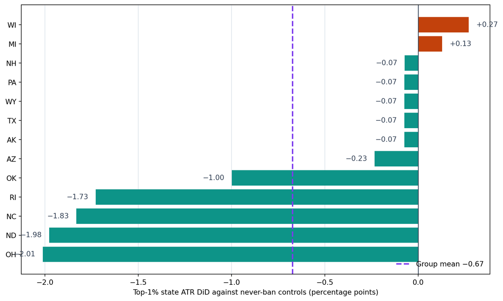

Figure 1: State-level DiDs in the corporate-and-union-ban group

Table 5: State-level DiDs underlying the corporate-and-union group mean

| State | DiD (percentage points) |
| --- | --- |
| OH | −2.011 |
| ND | −1.977 |
| NC | −1.832 |
| RI | −1.727 |
| OK | −0.999 |
| AZ | −0.233 |
| AK | −0.074 |
| TX | −0.074 |
| WY | −0.074 |
| PA | −0.074 |
| NH | −0.072 |
| MI | +0.129 |
| WI | +0.272 |

The mean of the 13 state estimates in Figure 1 and Table 5 is −0.673, equal to the baseline corporate-and-union coefficient up to stored precision. The most negative state contrasts are OH, ND, NC, RI, OK. Several other states contribute near-zero or positive changes, so this average should not be read as a uniform response.

## 4.1 Leave-out diagnostics

Table 6: Leave-one-state-out corporate-and-union estimates

| State omitted | Top-1% ATR | Reynolds–Smolensky |
| --- | --- | --- |
| AK | −0.723 | −0.095 |
| AZ | −0.709 | −0.093 |
| MI | −0.740 | −0.097 |
| NC | −0.576 | −0.074 |
| ND | −0.564 | −0.076 |
| NH | −0.723 | −0.095 |
| OH | −0.561 | −0.076 |
| OK | −0.646 | −0.093 |
| PA | −0.723 | −0.093 |
| RI | −0.585 | −0.082 |
| TX | −0.723 | −0.095 |
| WI | −0.751 | −0.099 |
| WY | −0.723 | −0.095 |

Table 7: Jointly excluding North Carolina, North Dakota, and Ohio

| Outcome | Estimate | Clustered SE | p-value |
| --- | --- | --- | --- |
| ATR, top 1% by AGI | −0.293 | 0.236 | 0.221 |
| Reynolds–Smolensky | −0.039 | 0.025 | 0.123 |

No single omission in Table 6 reverses the top-percentile result: the coefficient ranges from −0.751 to −0.561. Jointly excluding the reformers shown in Table 7, however, yields the materially smaller and statistically imprecise estimates in Table 7.

# 5 Trends

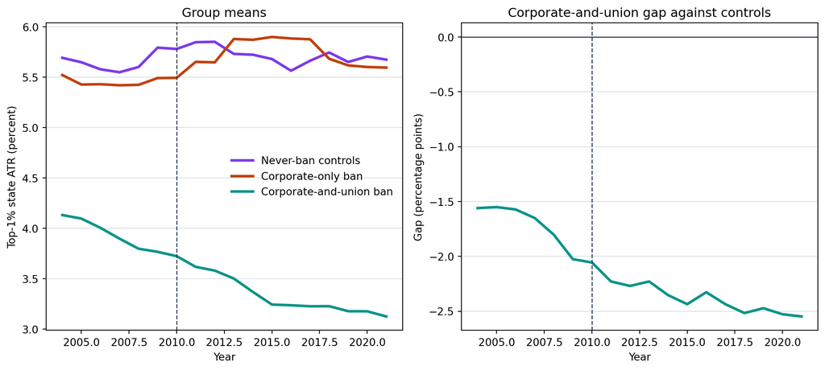

Figure 2: Top-percentile ATR group means and the corporate-and-union gap

The raw corporate-and-union gap in Figure 2 is −1.560 at the start of the panel, −2.026 in the omitted event-study year, and −2.548 at the end. The widening before the ruling is visible in levels and motivates caution about the parallel-trends interpretation.

Table 8: Event-study leads and lags relative to the omitted year

| Year | Top-1% ATR: corporate and union | Top-1% ATR: corporate only | RS: corporate and union | RS: corporate only |
| --- | --- | --- | --- | --- |
| 2004 | 0.465 (0.256) | 0.130 (0.204) | 0.053 (0.033) | 0.031 (0.026) |
| 2005 | 0.476 (0.234) | 0.081 (0.148) | 0.058 (0.031) | 0.028 (0.020) |
| 2006 | 0.453 (0.211) | 0.154 (0.156) | 0.052 (0.029) | 0.030 (0.020) |
| 2007 | 0.374 (0.178) | 0.173 (0.147) | 0.034 (0.024) | 0.025 (0.016) |
| 2008 | 0.223 (0.141) | 0.124 (0.133) | 0.022 (0.018) | 0.018 (0.014) |
| 2009 | Reference | Reference | Reference | Reference |
| 2010 | −0.031 (0.067) | 0.016 (0.058) | −0.000 (0.010) | −0.001 (0.008) |
| 2011 | −0.203 (0.134) | 0.107 (0.185) | −0.023 (0.016) | 0.036 (0.043) |
| 2012 | −0.244 (0.157) | 0.098 (0.201) | −0.036 (0.021) | 0.032 (0.045) |
| 2013 | −0.203 (0.217) | 0.451 (0.372) | −0.030 (0.027) | 0.076 (0.048) |
| 2014 | −0.328 (0.263) | 0.451 (0.372) | −0.046 (0.036) | 0.081 (0.051) |
| 2015 | −0.410 (0.297) | 0.521 (0.379) | −0.066 (0.039) | 0.078 (0.054) |
| 2016 | −0.302 (0.298) | 0.622 (0.384) | −0.057 (0.037) | 0.089 (0.052) |
| 2017 | −0.409 (0.285) | 0.515 (0.372) | −0.062 (0.036) | 0.069 (0.047) |
| 2018 | −0.491 (0.288) | 0.240 (0.346) | −0.083 (0.037) | 0.015 (0.053) |
| 2019 | −0.448 (0.314) | 0.268 (0.362) | −0.072 (0.038) | 0.027 (0.056) |
| 2020 | −0.503 (0.302) | 0.198 (0.356) | −0.076 (0.037) | 0.018 (0.059) |
| 2021 | −0.521 (0.333) | 0.223 (0.371) | −0.083 (0.042) | 0.020 (0.066) |

Table 8 reports coefficient and clustered standard error for each lead and lag; 2009 is the omitted category. The pre-period corporate-and-union top-percentile coefficients move from 0.465 to 0.223 before reaching zero in the reference year. The committed event-study artifact does not contain the covariance matrix required to reconstruct joint lead or lag tests, so this report does not infer those tests from marginal standard errors.

## 5.1 Differential linear pre-trend

A joint test of the five event-study leads has little power against a monotone drift. Table 9 reports the pre-period (2004–2009) slope of each ban group relative to controls, from `results/pretrend_tests.csv`, with state-clustered standard errors.

Table 9: Differential linear pre-trend, 2004–2009 (slope per year relative to never-ban controls; state-clustered SEs)

|  | Sample | Outcome | N | Corporate & union ban | Corporate-only ban |
| --- | --- | --- | --- | --- | --- |
| 0 | Main (47 units) | atr_top1 | 282 | -0.090 (0.053), p = 0.089 | -0.014 (0.036), p = 0.690 |
| 1 | Main (47 units) | atr_top5 | 282 | -0.060 (0.043), p = 0.162 | -0.000 (0.028), p = 0.998 |
| 2 | Main (47 units) | rs | 282 | -0.011 (0.007), p = 0.096 | -0.005 (0.005), p = 0.264 |
| 3 | Main (47 units) | beta | 282 | -0.074 (0.049), p = 0.132 | -0.010 (0.038), p = 0.787 |
| 4 | Income-tax states only | atr_top1 | 234 | -0.128 (0.068), p = 0.062 | -0.016 (0.041), p = 0.691 |
| 5 | Income-tax states only | atr_top5 | 234 | -0.088 (0.055), p = 0.108 | -0.000 (0.032), p = 0.995 |
| 6 | Income-tax states only | rs | 234 | -0.014 (0.009), p = 0.097 | -0.006 (0.006), p = 0.265 |
| 7 | Income-tax states only | beta | 234 | -0.089 (0.066), p = 0.179 | -0.011 (0.042), p = 0.795 |

The corporate-and-union slope on the top-1% ATR is −0.09 pp per year (p = 0.089; −0.13, p = 0.062 among income-tax states), against a post-2010 differential of about −0.045 pp per year; the corporate-only slopes are indistinguishable from zero.

# 6 Incidence

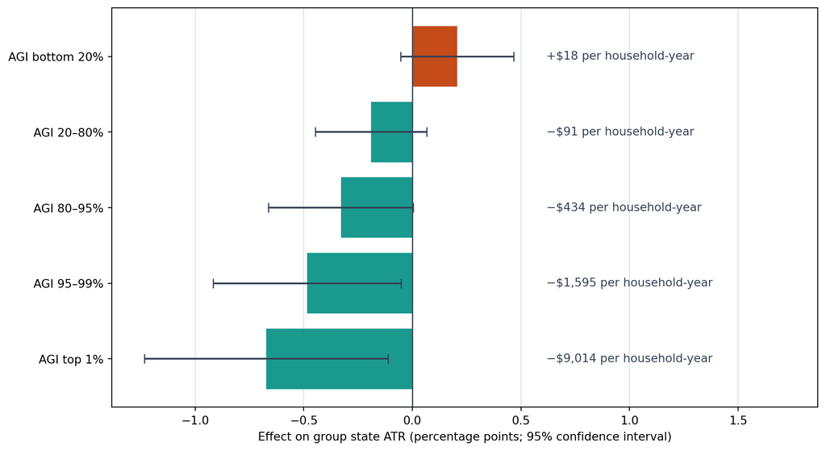

Figure 3: Income-gradient estimates in corporate-and-union-ban states

Table 10: Subgroup incidence estimates

| Group | Corporate-only estimate | Corporate-and-union estimate (SE) | p-value | Mean AGI, source-year dollars | Dollar effect per household-year |
| --- | --- | --- | --- | --- | --- |
| AGI bottom 20% | −0.199 | 0.206 (0.133) | 0.128 | $8,649 | +$18 |
| AGI 20–80% | 0.133 | −0.190 (0.131) | 0.152 | $47,929 | −$91 |
| AGI 80–95% | 0.130 | −0.329 (0.170) | 0.059 | $132,064 | −$434 |
| AGI 95–99% | 0.158 | −0.484 (0.221) | 0.034 | $329,408 | −$1,595 |
| AGI top 1% | 0.199 | −0.673 (0.286) | 0.023 | $1,340,002 | −$9,014 |
| Net worth top 5% | 0.181 | −0.583 (0.254) | 0.026 | $437,316 | −$2,549 |
| Net worth top 1% | 0.162 | −0.662 (0.279) | 0.022 | $957,239 | −$6,336 |
| Capital share above 50%, AGI above $50,000 | 0.053 | −0.530 (0.224) | 0.022 | $411,063 | −$2,179 |
| Capital share below 10%, AGI above $50,000 | 0.162 | −0.392 (0.182) | 0.037 | $129,470 | −$508 |
| Wage share above 90%, AGI top 5% | 0.170 | −0.544 (0.232) | 0.024 | $467,640 | −$2,543 |
| Head age 65 or older | 0.185 | −0.307 (0.166) | 0.071 | $63,039 | −$194 |
| Married with children | 0.134 | −0.359 (0.174) | 0.045 | $106,511 | −$382 |

The AGI-ranked rows of Table 10 form the monotone income gradient drawn in Figure 3. The top-percentile household estimate corresponds to −$9,014 per household-year at the committed group mean AGI. These are public-reconstruction estimates from a fixed household sample, not estimates reported by the paper and not independent household-level treatment observations.

Table 11: Top-minus-bottom ATR slope estimate

| Term | Estimate (clustered SE) | p-value | N |
| --- | --- | --- | --- |
| CU × CorpOnly | 0.357 (0.396) | 0.372 | 846 |
| CU × CorpUnion | −0.679*** (0.219) | 0.003 | 846 |

The paper defines β in its equation (5) but does not report it in Table 4. In the committed panel, the corporate-and-union estimate in Table 11 is −0.679*** (0.219).

# 7 Union-density moderator

Table 12: Union-density moderator specifications

| Outcome | Specification | Post × density | Corporate only | Corporate and union | Corporate and union × density | Corporate only × density |
| --- | --- | --- | --- | --- | --- | --- |
| ATR, top 1% by AGI | densOnly | 0.065 (p=0.003) | — | — | — | — |
|  | bans+dens | 0.064 (p=0.001) | 0.143 (p=0.592) | −0.674 (p=0.015) | — | — |
|  | bans+dens+within | 0.065 (p=0.004) | 0.080 (p=0.732) | −0.677 (p=0.014) | −0.023 (p=0.569) | 0.086 (p=0.239) |
| Reynolds–Smolensky | densOnly | 0.008 (p=0.003) | — | — | — | — |
|  | bans+dens | 0.008 (p=0.001) | 0.016 (p=0.690) | −0.089 (p=0.009) | — | — |
|  | bans+dens+within | 0.008 (p=0.005) | 0.006 (p=0.861) | −0.090 (p=0.008) | −0.003 (p=0.519) | 0.013 (p=0.220) |

# 8 Partisan-control horse race

The horse race asks whether the ban-group interactions proxy for the Republican-trifecta acquisition wave, contemporaneous or lagged partisan control, or the REDMAP state set. These are decomposition checks. Partisan control may itself respond to the ruling, so a surviving ban coefficient does not establish a causal mechanism.

Table 13: Primary partisan-control horse-race specifications

| Outcome | Specification | Corporate and union | Corporate only | Added term or terms | Move toward zero from baseline | N |
| --- | --- | --- | --- | --- | --- | --- |
| ATR, top 1% by AGI | (a) Baseline | −0.673** (0.286) | 0.199 (0.317) | — | 0.0% | 846 |
|  | (b) + CU x R-trifecta acquirer | −0.565* (0.303) | 0.169 (0.309) | CU × R-trifecta acquirer: −0.281 (0.246) | 16.1% | 846 |
|  | (c) + R trifecta (t) | −0.640** (0.292) | 0.210 (0.313) | R trifecta (t): −0.147 (0.125) | 4.8% | 846 |
|  | (c-lag) + R trifecta (t-1) | −0.602** (0.279) | 0.214 (0.305) | R trifecta (t-1): −0.205 (0.124) | 10.5% | 799 |
|  | (d) + CU x REDMAP | −0.736** (0.336) | 0.199 (0.318) | CU × REDMAP: 0.138 (0.509) | −9.5% | 846 |
|  | (e) + acquirer and REDMAP | −0.673* (0.369) | 0.165 (0.309) | CU × R-trifecta acquirer: −0.322 (0.219); CU ×... | 0.0% | 846 |
|  | (f) Acquirer + REDMAP; no ban terms | — | — | CU × R-trifecta acquirer: −0.444** (0.199); CU... | — | 846 |
|  | (g) Restricted + R trifecta (t) | −0.649** (0.293) | — | R trifecta (t): −0.105 (0.139) | 3.5% | 702 |
|  | (g-lag) Restricted + R trifecta (t-1) | −0.616** (0.279) | — | R trifecta (t-1): −0.143 (0.138) | 8.5% | 663 |
| Reynolds–Smolensky | (a) Baseline | −0.089** (0.035) | 0.023 (0.046) | — | 0.0% | 846 |
|  | (b) + CU x R-trifecta acquirer | −0.072* (0.036) | 0.018 (0.045) | CU × R-trifecta acquirer: −0.045 (0.031) | 19.5% | 846 |
|  | (c) + R trifecta (t) | −0.083** (0.036) | 0.025 (0.045) | R trifecta (t): −0.028* (0.015) | 7.0% | 846 |
|  | (c-lag) + R trifecta (t-1) | −0.078** (0.034) | 0.027 (0.045) | R trifecta (t-1): −0.039** (0.016) | 13.1% | 799 |
|  | (d) + CU x REDMAP | −0.085** (0.038) | 0.023 (0.046) | CU × REDMAP: −0.010 (0.061) | 5.1% | 846 |
|  | (e) + acquirer and REDMAP | −0.075* (0.044) | 0.018 (0.045) | CU × R-trifecta acquirer: −0.047 (0.028); CU ×... | 15.5% | 846 |
|  | (f) Acquirer + REDMAP; no ban terms | — | — | CU × R-trifecta acquirer: −0.060** (0.025); CU... | — | 846 |
|  | (g) Restricted + R trifecta (t) | −0.085** (0.036) | — | R trifecta (t): −0.020 (0.016) | 4.9% | 702 |
|  | (g-lag) Restricted + R trifecta (t-1) | −0.080** (0.034) | — | R trifecta (t-1): −0.028 (0.017) | 10.4% | 663 |

Table 14: Republican-trifecta acquisition counts by ban group

| Acquisition status | Corporate and union | Corporate only | Never-ban controls |
| --- | --- | --- | --- |
| Acquired in the post-ruling wave | 8 | 1 | 6 |
| Did not acquire | 5 | 7 | 20 |

Table 14 shows that 8 of 13 corporate-and-union states acquired a Republican trifecta, compared with 1 of 8 corporate-only states and 6 of 26 controls.

In Table 13, adding the acquisition-wave term moves the top-percentile corporate-and-union estimate from −0.673 to −0.565, an attenuation of 16.1%. The coefficient remains similar in magnitude across the contemporaneous, lagged, REDMAP, combined, and restricted specifications. Its exact conventional significance level varies across specifications.

# 9 Caveats and not-done items

- The reconstruction uses 1 SCF implicate. It does not propagate between-implicate sampling uncertainty.
- The public summary extract is not the authors’ LWS harmonization. Spouse wages, interest and dividends, Social Security and pensions, and itemized deductions cannot all be separated as in a richer microdata file.
- The reconstruction uses the currently available TAXSIM build. State-law encodings can change across vintages, and the resulting state income-tax liability excludes local income taxes.
- The committed result grid contains 4 sample-and-dating variants. Alternative dating is available only for the main sample, not as a complete cross-product with every sample restriction.
- The micro-incidence CSV preserves subgroup results, but the underlying household-level TAXSIM outputs are not committed. Most subgroup rows therefore cannot be regenerated from the state-year panel alone.
- The event-study CSV preserves marginal coefficients and standard errors, not the full covariance matrix. Joint lead and lag tests are intentionally not reconstructed from insufficient information.
- The union-density CSV omits the underlying state density panel, and the inference summaries omit the randomization and bootstrap draws.
- Synthetic difference-in-differences, after-federal-tax outcomes, state-specific trend specifications, and multiple-implicate inference were not re-estimated here.
- Partisan-control specifications are potentially post-treatment controls. They are useful proxy and decomposition checks, not clean causal tests of a partisan channel.

# Appendix

## Exact commands

The fast path starts from the committed state-year panel:

```bash
cd replication
uv sync
uv run cu-replication estimate
```

The full reconstruction runs the stages explicitly and requires R only for TAXSIM:

```bash
cd replication
uv run cu-replication download
uv run cu-replication build-inputs
uv run cu-replication taxsim
uv run cu-replication outcomes
uv run cu-replication estimate
uv run cu-replication figures
```

Tests, static checks, and report rendering use:

```bash
cd replication
uv run pytest -q
uv run ruff check .
quarto render report
```

## Software versions

Table 15: Software versions detected while rendering

| Software | Version |
| --- | --- |
| Python | 3.14.4 |
| cu-replication | 0.1.0 |
| pandas | 2.3.3 |
| NumPy | 2.4.3 |
| statsmodels | 0.14.6 |
| Matplotlib | 3.10.8 |
| pytest | 8.4.2 |
| ruff | 0.15.22 |
| Quarto | 1.9.36 |
| R | Rscript (R) version 4.3.0 (2023-04-21) |

Table 15 records the versions detected in the rendering environment.

## File manifest

Table 16: Committed CSV artifacts available to the report

| File | Rows | Columns | Size (KiB) |
| --- | --- | --- | --- |
| ../results/event_study.csv | 144 | 5 | 8.5 |
| ../results/group_means_by_year.csv | 18 | 9 | 1.1 |
| ../results/illustrative_reforms.csv | 8 | 11 | 0.8 |
| ../results/inference_summary.csv | 2 | 8 | 0.2 |
| ../results/leave_out.csv | 32 | 4 | 1.6 |
| ../results/micro_heterogeneity.csv | 12 | 7 | 0.6 |
| ../results/panel_state_year.csv | 918 | 9 | 109.7 |
| ../results/per_state_did.csv | 42 | 4 | 1.7 |
| ../results/pretrend_tests.csv | 8 | 9 | 1.2 |
| ../results/randomization_inference.csv | 2 | 6 | 0.2 |
| ../results/table4_replication.csv | 24 | 14 | 5.3 |
| ../results/union_density_moderator.csv | 6 | 12 | 0.4 |
| ../horserace/acquirer_list.csv | 51 | 7 | 1.5 |
| ../horserace/acquisition_counts.csv | 2 | 4 | 0.1 |
| ../horserace/baseline.csv | 8 | 13 | 1.6 |
| ../horserace/descriptive_changes.csv | 12 | 4 | 0.6 |
| ../horserace/horserace_models.csv | 56 | 27 | 18.6 |
| ../horserace/horserace_tidy.csv | 116 | 13 | 26.3 |
| ../horserace/key_models.csv | 36 | 27 | 13.9 |
| ../horserace/no_ban_models.csv | 20 | 27 | 5.4 |
| ../horserace/partisan_control.csv | 918 | 8 | 130.2 |
| ../horserace/placebo_summary.csv | 4 | 28 | 2.3 |
| ../horserace/sanity_checks.csv | 8 | 2 | 0.3 |
| ../horserace/source_coverage.csv | 36 | 5 | 4.5 |
| ../horserace/state_changes.csv | 47 | 6 | 2.8 |

Table 16 lists the committed result artifacts, including diagnostic files not displayed in the main report. TAXSIM micro outputs and randomization draw files are not part of the committed report input set.